# Exploração do clima em João Pessoa, Campina Grande e Patos - PB

```r
library(tidyverse)
library(here)
library(gridExtra)
theme_set(theme_bw())
```

```r
# SEMPRE read_csv NUNCA read.csv
clima_tudo = read_csv(
    here("data/tempo-jp-cg-pt.csv"),
    col_types = cols(
        .default = col_double(),
        cidade = col_character(),
        semana = col_date(format = ""),
        ano = col_integer(),
        mes = col_integer()
    )
)

clima = clima_tudo %>%
    filter(ano == 2019)
```

### Considerando os meses de férias normais da UFCG e escolhendo uma das cidades (a mais próxima de onde você passa férias), quais as semelhanças e diferenças entre a temperatura e as chuvas nos meses de férias e nos meses de aula? Quando o clima é melhor?

*Para responder esta pergunta foram utilizados os dados da cidade de Campina Grande do ano de 2019, selecionando a temperatura média e quantidade de chuva semanais dos meses de férias, filtrados a partir dos dados originais. Os meses de férias normais da UFCG são entre Dezembro e Março, e entre Julho e Agosto.*

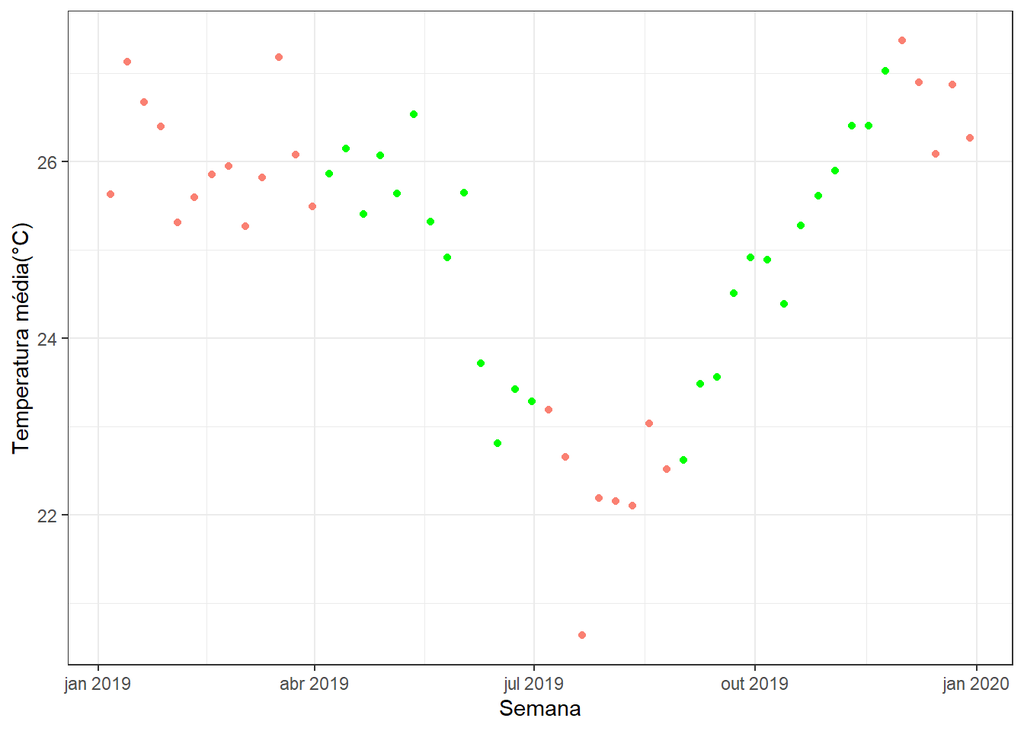

```r
temperatura_ferias = clima_tudo %>%
    filter(ano == 2019) %>%
    filter(mes == 1 | mes == 2 | mes == 3
           | mes == 7 | mes == 8 | mes == 12) %>%
    filter(cidade == "Campina Grande") %>%
    select(temp_media, semana, temp_min, mes)

temperatura_aulas = clima_tudo %>%
    filter(ano == 2019) %>%
    filter(mes == 4 | mes == 5 | mes == 6
           | mes == 9 | mes == 10 | mes == 11) %>%
    filter(cidade == "Campina Grande") %>%
    select(temp_media, semana, temp_min, mes)


clima %>% ggplot(aes(x = semana, y = temp_media)) +
          geom_point(data = temperatura_ferias,
                    aes(y=temp_media), colour="salmon") +
          geom_point(data = temperatura_aulas,
                    aes(y=temp_media), colour="green") +
          labs(
              x = "Semana",
              y = "Temperatura média(°C)"
          )
```

```r
chuva_ferias = clima_tudo %>%
    filter(ano == 2019) %>%
    filter(mes == 1 | mes == 2 | mes == 3
           | mes == 7 | mes == 8 | mes == 12) %>%
    filter(cidade == "Campina Grande") %>%
    select(chuva, semana)

chuva_aulas = clima_tudo %>%
    filter(ano == 2019) %>%
    filter(mes == 4 | mes == 5 | mes == 6
           | mes == 9 | mes == 10 | mes == 11) %>%
    filter(cidade == "Campina Grande") %>%
    select(chuva, semana)
```

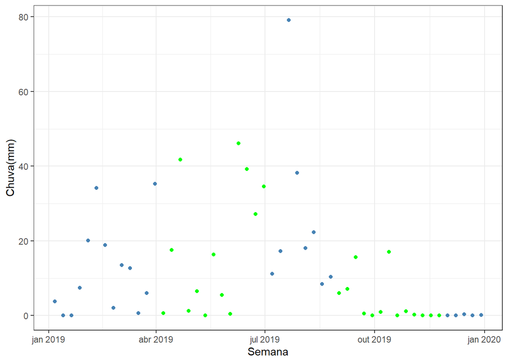

```r
clima %>% ggplot(aes(x = semana, y = chuva)) +
          geom_point(data = chuva_ferias,
                    aes(y=chuva), colour="steelblue") +
          geom_point(data = chuva_aulas,
                    aes(y=chuva), colour="green") +
          labs(
              x = "Semana",
              y = "Chuva(mm)"
          )
```

**É possível observar que a quantidade de chuva nos meses de férias e de aula assumiu uma faixa de valores semelhante, tendo um único ponto mais extremo no mês de férias. Estes valores se tornaram praticamente iguais nas semanas dos meses entre Novembro e Janeiro.**

```r
sumario_ferias = temperatura_ferias %>%
    group_by(mes)%>%
    summarise(temp_minima = min(temp_media),
              .groups = "drop")

sumario_aulas = temperatura_aulas %>%
    group_by(mes)%>%
    summarise(temp_minima = min(temp_media),
              .groups = "drop")
```

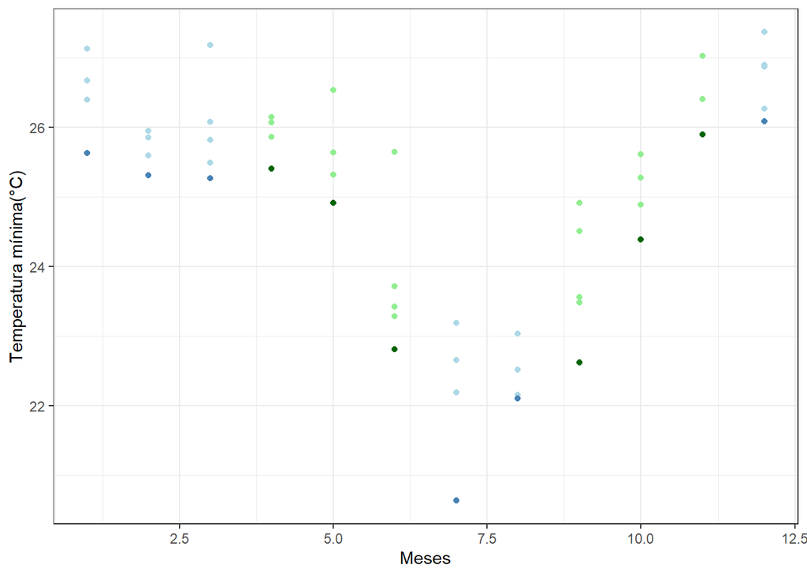

```r
clima %>% ggplot(aes(x = mes, y = temp_min)) +
          geom_point(data = temperatura_ferias,
                    aes(y=temp_media), colour="lightblue") +
          geom_point(data = temperatura_aulas,
                    aes(y=temp_media), colour="lightgreen") +
          geom_point(data = sumario_ferias,
                     aes(y = temp_minima), colour="steelblue") +
          geom_point(data = sumario_aulas,
                     aes(y = temp_minima), colour="darkgreen") +
          labs(
              x = "Meses",
              y = "Temperatura mínima(°C)"
          )
```

**Para observar em qual época o clima foi melhor, foi medido a temperatura mínima da temperatura média de cada mês. É possível observar que as temperatura mais baixas foram entre os meses de depois de Junho e antes de Outubro. Considerando que um clima bom é quando a temperatura está abaixo dos 24 graus, a época com um melhor clima é entre as férias do meio do ano.**

### Compare o quanto as cidades de Campina Grande, João Pessoa e Patos têm meses claramente mais quentes/frios. Em qual delas há épocas mais diferentes?

*Para responder esta pergunta foram utilizados os dados das cidades de Campina Grande, João Pessoa e Patos do ano de 2019, selecionando as temperaturas máxima, média e mínima filtradas a partir dos dados originais.*

```r
sumario = clima %>%
    group_by(cidade, mes)%>%
    summarise(temp_min = min(temp_media),
              temp_max = max(temp_media),
              temp_min = min(temp_media),
              .groups = "drop")
```

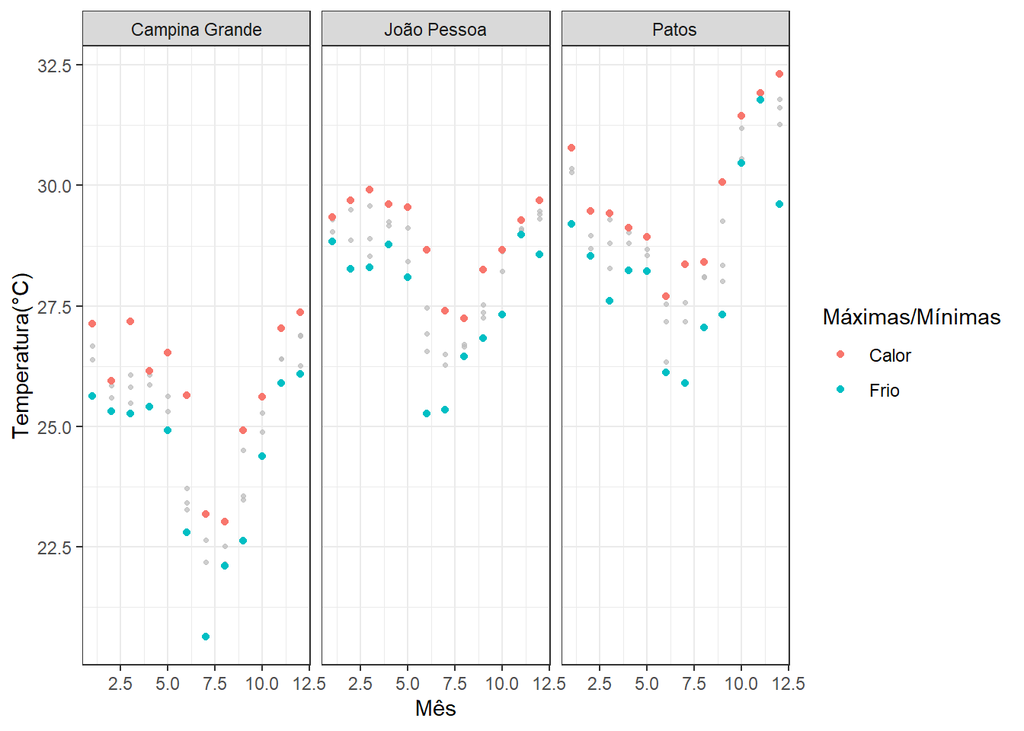

```r
clima %>%
    ggplot(aes(x = mes, y = temp_media)) +
    facet_wrap(~ cidade) +
    geom_point(alpha = .75, size = .9, color = "grey") +
    geom_point(data = sumario, aes(y = temp_max, colour = "Calor")) +
    geom_point(data = sumario, aes(y = temp_min, colour = "Frio")) +

    labs(
        x = "Mês",
        y = "Temperatura(°C)",
        color = "Máximas/Mínimas"
    )
```

**É possivel observar que Campina Grande teve meses mais frios do que Patos e João Pessoa, enquanto a quantidade de meses quentes e frios em Patos e João Pessoa se assemelham entre si.** **Campina Grande é a cidade onde as épocas são mais discrepantes quando comparadas as outras duas cidades, onde o calor é mais ameno e o frio mais acentuado.**

### Compare a diferença de umidade mensal em João Pessoa, Campina Grande e Patos. Em qual delas a umidade é mais baixa/alta?

```r
sumario = clima %>%
    group_by(cidade, mes)%>%
    summarise(umidade_media = mean(umidade),
              .groups = "drop")
```

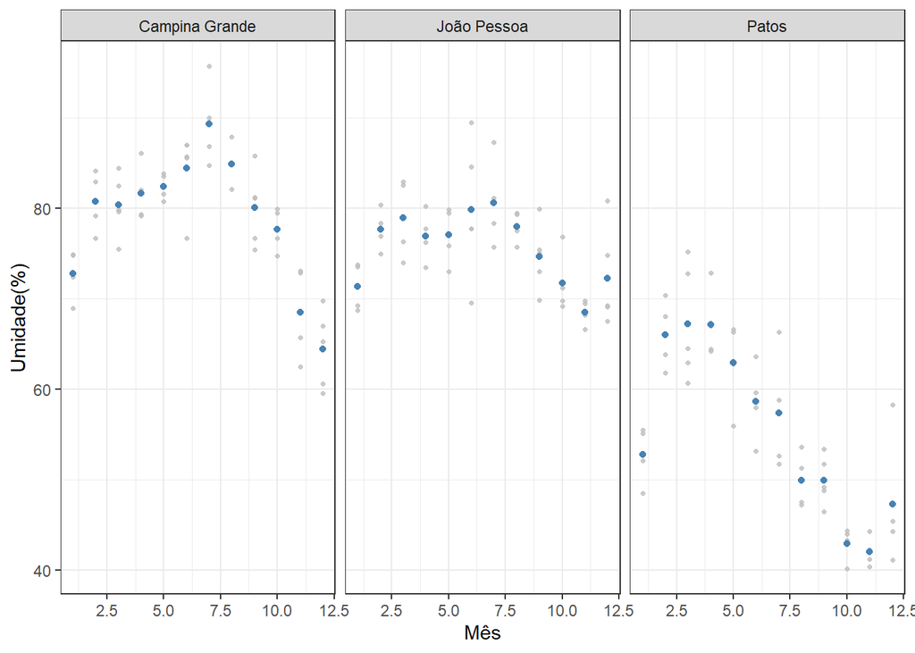

```r
clima %>%
    ggplot(aes(x = mes, y = umidade)) +
    facet_wrap(~ cidade) +
    geom_point(alpha = .8, size = .9, color = "grey") +
    geom_point(data = sumario, aes(y = umidade_media),
               color = "steelblue" ) +
    labs(
        x = "Mês",
        y = "Umidade(%)"
    )
```

**A média da umidade mensal em Patos assumiu valores mais baixos, porém apresentando uma maior variação na faixa de valores quando comparado com as outras duas cidades. A média de umidade mensal em João Pessoa se manteve estável e com pouca variação na faixa de valores. Em contrapartida, Campina Grande apresentou os maiores valores de umidade mensal. É possível concluir que a cidade mais úmida foi, de fato, Campina Grande, enquanto Patos foi a menos úmida.**